# Airbnb & Zillow Data Challenge

## Contents:

#### 1. Problem Statement

#### 2. Defining Profitability

#### 3. Executive Summary

#### 4. Assumptions Made

#### 5. Data & Package Importing

- (5.1) Importing Required Packages
- (5.2) Importing Airbnb & Zillow Data
- (5.3) Importing NYC ZIP Codes & Boundaries

#### 6. Data Cleaning, Quality Check & Analytical Datasets Creation

- (6.1) Airbnb Data
- (6.2) Zillow Data

#### 7. Exploratory Data Analysis (EDA)

- (7.1) Objective
- (7.2) Airbnb Data
  - (7.2.1) Borough Level
  - (7.2.2) ZIP Code Level
- (7.3) Zillow Data

#### 8. Profitability Analysis: Absolute Influence of the Airbnb Listing Business

- (8.1) Assumptions
- (8.2) Borough Level
- (8.3) ZIP Code Level

#### 9. Profitability Analysis: Multi-factor Assessment of Profitability

- (9.1) Borough Level Effect of Time
- (9.2) ZIP Code Level Effect of Time
- (9.3) Time Series Forecasting at ZIP Code Level
- (9.4) Plotting Net Present Value (NPV) over Time

#### 10. Recommendations

#### 11. Next Steps

#### 12. References

## 1. Problem Statement

> You are consulting for a real estate company that has a niche in purchasing properties to rent out short-term as part of their business model specifically within New York City. The real estate company has already concluded that two bedroom properties are the most profitable; however, they do not know which zip codes are the best to invest in.

> The real estate company has engaged your firm to build out a data product and provide your conclusions to help them understand which zip codes would generate the most profit on short term rentals within New York City.

## 2. Defining Profitability

> For this problem, we define profitability as:
> - **Long term perspective:**
>   - Capacity to generate the largest incremental profit in the long run
> - **Short term perspective:**
>   - Least time taken to break-even with the initial investment

## 3. Executive Summary

> - Investment in property is most profitable around the Upper East Side of Manhattan (ZIP codes: 10028, 10128) in terms of breaking even from initial investment the earliest, as well as in term of greater incremental profits in the long run.
>   - An investment in a property in this area is estimated to break-even in around 6 years, and be valued at ~$2M USD (in profits) in around 12 years (inclusive of revenue from short term Airbnb rentals).
> - Investment in property is also highly profitable around the southern side of the Upper East Side of Manhattan (ZIP code: 10022) and around the Upper West Side of Manhattan (ZIP code: 10023).
>   - An investment in a property in this area is estimated to break-even in around 8 years, and be valued at ~$1.3M USD (in profits) in around 12 years (inclusive of revenue from short term Airbnb rentals).
> - Diversification of investment among these ZIP codes is highly recommended to minimize risk.

## 4. Assumptions Made

> - Fixed Assumptions:
>   - The investor will pay for the property in cash (i.e. no mortgage/interest rate will be accounted for)
>   - The time value of money / discount rate is 0%
> - Additional Assumption:
>   - There is no seasonal effect on AirBnb occupancy rates. Hence the short term occupancy rate for an Airbnb listing is derived from the number of days available to book within the next 30 days (Column: 'availability_30')
>   - Current period of time is May, 2017

## 5. Data Loading

### (5.1) Importing Required Packages

```python
%matplotlib inline

import warnings
warnings.filterwarnings('ignore')

import pandas as pd
from pandas import *

from geopandas import GeoDataFrame

import matplotlib.pyplot as plt
import matplotlib

import seaborn as sns

import numpy as np
from numpy import nan

from bokeh.io import show, output_notebook
from bokeh.models import LinearAxis, Range1d, NumeralTickFormatter, Legend
from bokeh.layouts import row
from bokeh.palettes import Viridis256, Dark2_5 as palette
from bokeh.plotting import figure, output_file, show
output_notebook()

import os
import itertools

from pylab import rcParams
import statsmodels.api as sm
```

### (5.2) Importing Airbnb & Zillow Data

**[Airbnb Source](http://insideairbnb.com/get-the-data.html)**

**[Zillow Source](https://www.zillow.com/research/data/)**

Please input the required directory and dataset names:

```python
dir1 = input("Enter directory of required datasets:")
# C:\Users\andre\Desktop\C1_DC\Datasets
airbnb_orig = input("Enter the name of the AirBnB Listings CSV:")
# listings
zillow_orig = input("Enter the name of the Zillow Pricing CSV:")
# Zip_Zhvi_2bedroom

# removing leading and trailing spaces
dir1 = dir1.strip()
airbnb_orig = airbnb_orig.strip()
zillow_orig = zillow_orig.strip()

# loading datasets
os.chdir(dir1)
airbnb = pd.read_csv(airbnb_orig+'.csv', low_memory=False)
zillow = pd.read_csv(zillow_orig+'.csv', low_memory=False)
```

```
Enter directory of required datasets:C:\Users\andre\Desktop\C1_DC\Datasets
Enter the name of the AirBnB Listings CSV:listings
Enter the name of the Zillow Pricing CSV:Zip_Zhvi_2bedroom
```

### (5.3) Importing NYC ZIP Codes & Boundaries

**[NYCOpenData Source](https://data.cityofnewyork.us/Business/Zip-Code-Boundaries/i8iw-xf4u/data)**

This data is imported to get the ZIP codes of NYC and information on their boundaries (for plotting and mapping)

```python
# loading dataset
zip_codes = GeoDataFrame.from_file('ZIP_CODE_040114/ZIP_CODE_040114.shp')
zip_codes['zip_code'] = zip_codes['ZIPCODE'].astype(int)
zip_codes_inter = pd.DataFrame(zip_codes['zip_code'])
zip_codes_nyc = pd.DataFrame(zip_codes_inter['zip_code'].unique(), columns = ['zipcode']).astype(int)
print(zip_codes_nyc.dtypes)
print(zip_codes_nyc.shape)
```

```
zipcode    int32
dtype: object
(248, 1)
```

## 6. Data Cleaning, Quality Check & Analytical Datasets Creation

### (6.1) Airbnb Dataset

#### The dataset is explored to gain a better understanding on the type and quality of data that is available

```python
print("Dimensions of AirBnB dataset:", airbnb.shape)
print("Unique 'id' values in AirBnB dataset:", len(airbnb.groupby('id').size()))
pd.set_option('display.max_rows', 2)
pd.set_option('display.max_columns', 500)
pd.set_option('display.width', 1000)
airbnb
```

```
Dimensions of AirBnB dataset: (40753, 95)
Unique 'id' values in AirBnB dataset: 40753
```

|  | id | listing_url | scrape_id | last_scraped | name | summary | space | description | experiences_offered | neighborhood_overview | notes | transit | access | interaction | house_rules | thumbnail_url | medium_url | picture_url | xl_picture_url | host_id | host_url | host_name | host_since | host_location | host_about | host_response_time | host_response_rate | host_acceptance_rate | host_is_superhost | … |
| --- | --- | --- | --- | --- | --- | --- | --- | --- | --- | --- | --- | --- | --- | --- | --- | --- | --- | --- | --- | --- | --- | --- | --- | --- | --- | --- | --- | --- | --- | --- |
| 0 | 7949480 | https://www.airbnb.com/rooms/7949480 | 20170502132028 | 2017-05-03 | City Island Sanctuary relaxing BR & Bath w Par... | Come relax on City Island in our quiet guest r... | On parle français et anglais, (lire Français c... | Come relax on City Island in our quiet guest r... | none | City Island is a unique sanctuary in New York ... | We are walkable to Pelham Park which is the la... | On the island, you can walk to everything. A ... | Feel free to enjoy our large backyard in seaso... | We speak fluent French and English. We will b... | No extra guests or visitors who are not in the... | https://a0.muscache.com/im/pictures/001d1cb0-6... | https://a0.muscache.com/im/pictures/001d1cb0-6... | https://a0.muscache.com/im/pictures/001d1cb0-6... | https://a0.muscache.com/im/pictures/001d1cb0-6... | 119445 | https://www.airbnb.com/users/show/119445 | Linda & Didier | 2010-05-06 | New York, New York, United States | I am a designer, former instructor at a design... | within an hour | 100% | NaN | t | … |
| ... | ... | ... | ... | ... | ... | ... | ... | ... | ... | ... | ... | ... | ... | ... | ... | ... | ... | ... | ... | ... | ... | ... | ... | ... | ... | ... | ... | ... | ... | … |
| 40752 | 17360085 | https://www.airbnb.com/rooms/17360085 | 20170502132028 | 2017-05-03 | Phish bakers dozen | I will be renting two staterooms on my yacht f... | NaN | I will be renting two staterooms on my yacht f... | none | NaN | NaN | NaN | NaN | Guests have full access and I offer as much gu... | NaN | https://a0.muscache.com/im/pictures/300d6cac-7... | https://a0.muscache.com/im/pictures/300d6cac-7... | https://a0.muscache.com/im/pictures/300d6cac-7... | https://a0.muscache.com/im/pictures/300d6cac-7... | 86490267 | https://www.airbnb.com/users/show/86490267 | Pete | 2016-07-28 | U.S. Virgin Islands | Please see more reviews at my other listings a... | within an hour | 100% | NaN | t | … |

40753 rows × 95 columns

#### The number of unique "id"s is found to be the same as the number of total records in the dataset. Therefore, the dataset is considered to be at an Airbnb listing level.

```python
print(airbnb.groupby('calendar_last_scraped').size())
print(airbnb['calendar_last_scraped'].isnull().values.sum())
```

```
calendar_last_scraped
2017-05-02    2005
              ...
2017-05-05    4934
Length: 4, dtype: int64
0
```

#### All the records were last scraped on the first few days of May, 2017. Therefore, we consider this data to represent the month of May, 2017.

#### The ZIP code is then treated as it is the primary key variable for this problem. The dataset is also filtered for 2 bedroom listings in NYC as per the client's request.

```python
print('Dimensions before NULL value treating:',airbnb.shape)

# first remove nulls in zipcode
airbnb_sub_1 = airbnb.copy()
airbnb_sub_1 = airbnb[airbnb.zipcode.notnull()]
print('Dimensions after NULL value treating:',airbnb_sub_1.shape)

# check length of zipcodes
size = airbnb_sub_1.zipcode.map(lambda x: len(x)).max()
print('The maximum length of the zipcode column currently is:', size)

# taking first 5 characters
airbnb_sub_2 = airbnb_sub_1.copy()
airbnb_sub_2['zipcode'] = airbnb_sub_1.zipcode.str[:5]

# converting zipcode to numeric
airbnb_sub_3 = airbnb_sub_2.copy()
airbnb_sub_3['zipcode'] = pd.to_numeric(airbnb_sub_2['zipcode'], errors='coerce')
# remove nulls due to coerce
airbnb_sub_4 = airbnb_sub_3.copy()
airbnb_sub_4 = airbnb_sub_3[airbnb_sub_3.zipcode.notnull()]
airbnb_sub_4['zipcode'] = airbnb_sub_4['zipcode'].astype('int32')
print('Dimensions after treating for 5 numeric values:',airbnb_sub_4.shape)

# filtering for NYC and 2 bedroom listings
airbnb_nyczip = pd.merge(airbnb_sub_4, zip_codes_nyc, how='inner', left_on='zipcode', right_on='zipcode')
print('Dimensions after filtering for NYC ZIP codes:',airbnb_nyczip.shape)
airbnb_r2 = airbnb_nyczip[airbnb_nyczip['bedrooms'] == 2.0]
print('Dimensions after filtering for 2 bedroom listings:',airbnb_r2.shape)
```

```
Dimensions before NULL value treating: (40753, 95)
Dimensions after NULL value treating: (40142, 95)
The maximum length of the zipcode column currently is: 11
Dimensions after treating for 5 numeric values: (40141, 95)
Dimensions after filtering for NYC ZIP codes: (40126, 95)
Dimensions after filtering for 2 bedroom listings: (4831, 95)
```

#### Post strategic planning, only the required columns are filtered, and then checked for quality.

```python
airbnb_sub = airbnb_r2[['id','neighbourhood_group_cleansed','zipcode', 'square_feet','price','availability_30']]

# QC 'neighbourhood_group_cleansed' values
print(airbnb_sub['neighbourhood_group_cleansed'].unique())
# check if price is > 0
print(airbnb_sub[airbnb_sub['price']== 0]['price'].count())
# check max and min values of 'availability_30'
print(airbnb_sub['availability_30'].max(),airbnb_sub['availability_30'].min())
# have a look at the 'price' variable
print(airbnb_sub['price'].head())
# we have to convert this to numeric
airbnb_sub_2 = airbnb_sub.copy()
airbnb_sub_2['price'] = airbnb_sub['price'].replace('[\$,]', '', regex=True).astype(float)
print(airbnb_sub_2['price'].head())
# check what variables have null values
pd.set_option('display.max_rows', 10)
print(airbnb_sub_2.isnull().sum())
# drop column square_feet as most of the values are NULL
airbnb_sub_2 = airbnb_sub_2.drop(['square_feet'], axis=1)
print('Dimensions after subsetting and QC:',airbnb_sub_2.shape)
```

```
['Bronx' 'Queens' 'Brooklyn' 'Staten Island' 'Manhattan']
0
30 0
32    $100.00
       ...
74    $150.00
Name: price, Length: 5, dtype: object
32    100.0
      ...
74    150.0
Name: price, Length: 5, dtype: float64
id                                 0
neighbourhood_group_cleansed       0
zipcode                            0
square_feet                     4718
price                              0
availability_30                    0
dtype: int64
Dimensions after subsetting and QC: (4831, 5)
```

#### The distribution of 'price' is then plotted to test for outliers, since it is an important variable when analyzing profitability.

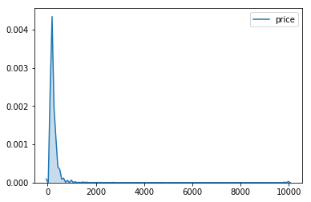

```python
sns.kdeplot(airbnb_sub_2["price"], shade=True)
```

#### The Airbnb rent ('price') is found to be right skewed with extreme values.

#### An intuitive explanation would be that the Airbnb rent ('price') in Manhattan is expected to be higher than that at Staten Island.

#### This hypothesis is then assessed for validity by plotting the distribution of the Airbnb rent ( 'price') among boroughs.

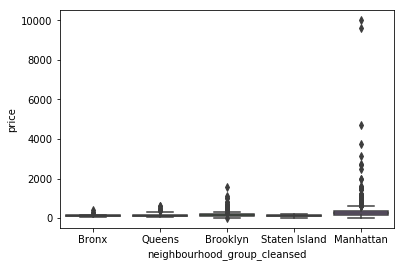

```python
ax = sns.boxplot(x="neighbourhood_group_cleansed", y="price", data=airbnb_sub_2)
```

#### It is observed that Manhattan, indeed, does contribute to extreme outliers.

#### The outliers within the dataset is then treated to prevent them from distorting hidden patterns.

```
Dimensions after outlier treatment: (4572, 5)
% of data retained post treatment 0.9463879114055062
```

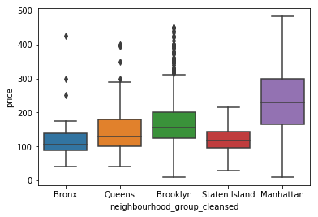

```python
# Filter out the extreme outliers
q25,q75 = airbnb_sub_2["price"].quantile([0.25,0.75]).values
iqr = q75 - q25
upper_bound_outlier = q75 + 1.5*iqr
lower_bound_outlier = q25 - 1.5*iqr
airbnb_no_outliers = airbnb_sub_2[(airbnb_sub_2['price'] < upper_bound_outlier) & (airbnb_sub_2['price'] > lower_bound_outlier)]
print('Dimensions after outlier treatment:',airbnb_no_outliers.shape)
print('% of data retained post treatment', airbnb_no_outliers.shape[0]/airbnb_sub_2.shape[0])
ax = sns.boxplot(x="neighbourhood_group_cleansed", y="price", data=airbnb_no_outliers)
```

#### Even post a conservative outlier treatment, is it observed that many extreme values still exists.

#### Since the mean is highly influenced by extreme values, it may not be the best approach to aggregate this data.

#### We assess this by analyzing the distribution of the Airbnb rent ('price') before and after the outlier treatment.

```python
# before outlier treatment
airbnb_sub_2.groupby('neighbourhood_group_cleansed').describe()['price']
```

| neighbourhood_group_cleansed | count | mean | std | min | 25% | 50% | 75% | max |
| --- | --- | --- | --- | --- | --- | --- | --- | --- |
| Bronx | 53.0 | 121.169811 | 62.296047 | 40.0 | 90.0 | 105.0 | 140.00 | 425.0 |
| Brooklyn | 2131.0 | 176.321445 | 91.849864 | 11.0 | 125.0 | 155.0 | 200.00 | 1600.0 |
| Manhattan | 2283.0 | 300.828734 | 372.114985 | 10.0 | 175.0 | 250.0 | 350.00 | 9999.0 |
| Queens | 334.0 | 147.979042 | 72.738019 | 40.0 | 100.0 | 134.5 | 180.00 | 600.0 |
| Staten Island | 30.0 | 118.766667 | 44.427146 | 28.0 | 96.0 | 117.5 | 144.75 | 215.0 |

```python
# after outlier treatment
airbnb_no_outliers.groupby('neighbourhood_group_cleansed').describe()['price']
```

| neighbourhood_group_cleansed | count | mean | std | min | 25% | 50% | 75% | max |
| --- | --- | --- | --- | --- | --- | --- | --- | --- |
| Bronx | 53.0 | 121.169811 | 62.296047 | 40.0 | 90.0 | 105.0 | 140.00 | 425.0 |
| Brooklyn | 2107.0 | 170.732795 | 70.384504 | 11.0 | 124.0 | 155.0 | 200.00 | 450.0 |
| Manhattan | 2051.0 | 239.176987 | 97.906956 | 10.0 | 165.0 | 229.0 | 300.00 | 482.0 |
| Queens | 331.0 | 144.187311 | 60.937683 | 40.0 | 100.0 | 130.0 | 179.00 | 400.0 |
| Staten Island | 30.0 | 118.766667 | 44.427146 | 28.0 | 96.0 | 117.5 | 144.75 | 215.0 |

#### It is observed from the above 2 tables that, before the outlier treatment, boroughs like Manhattan have the difference between mean and median around ~$50.

#### Whereas, after the outlier removal, the difference between mean and median is only ~$15 or less for all boroughs.

#### Hence, the median of Airbnb rent ('price') will be the aggregating methodology for this analysis to take a more conservative approach.

```python
print('# unique ZIP codes:', len(airbnb_no_outliers.groupby('zipcode').size()))
airbnb_zip_p1 = airbnb_no_outliers.groupby(['zipcode','neighbourhood_group_cleansed'],as_index=False).agg({'price':np.median})
print('# unique ZIP codes after aggregating at a ZIP code and borough level:', airbnb_zip_p1.shape[0])
```

```
# unique ZIP codes: 147
# unique ZIP codes after aggregating at a ZIP code and borough level: 149
```

#### It is observed that 1 or 2 ZIP codes are mapped to multiple boroughs.

#### Hence, these ZIP code(s) are assigned to it's 'true' borough, which is found after a study on NYC geographies.

#### Post the correction, since the primary objective is concerning ZIP codes, 2 main datasets are then created. One at an Airbnb listing level, and the other at a ZIP code aggregated level.

```python
dup = airbnb_zip_p1[airbnb_zip_p1.duplicated(subset='zipcode')]
# 10463 truly belongs to Bronx
# 11385 truly belongs to Queens
# updating airbnb_listing level data with info from google
airbnb_listing_corr = airbnb_no_outliers.copy()
airbnb_listing_corr.loc[airbnb_no_outliers['zipcode'] == 10463, 'neighbourhood_group_cleansed'] = 'Bronx'
airbnb_listing_corr.loc[airbnb_listing_corr['zipcode'] == 11385, 'neighbourhood_group_cleansed'] = 'Queens'
airbnb_listing = airbnb_listing_corr

# check distribution of availability_30 to decide whether to aggregate on mean or median
airbnb_listing.describe()['availability_30']
# since around 50% of the values are 2, we will take the conservative approach of using mean to aggregate

# final zipcode level aggregate data
# zipcode, neighbourhood_group_cleansed, median price level, num_listings
airbnb_zip = airbnb_listing.groupby(['zipcode','neighbourhood_group_cleansed'],as_index=False).agg({'price':np.median, 'id':'count', 'availability_30':np.mean})

# converting availability_30 into accupancy rate
airbnb_zip['availability_30'] = (1-airbnb_zip['availability_30']/30)
airbnb_listing['availability_30'] = (1-airbnb_listing['availability_30']/30)

# renaming columns
airbnb_zip = airbnb_zip.rename(columns = {'id':'num_listings','price':'airbnb_price','availability_30':'occupancy_rate', 'neighbourhood_group_cleansed':'Borough'})
airbnb_listing = airbnb_listing.rename(columns={'price':'airbnb_price', 'neighbourhood_group_cleansed':'Borough', 'availability_30':'occupancy_rate'})

print('Dimensions of main Airbnb ZIP level dataset:', airbnb_zip.shape)
print('Dimensions of main Airbnb listing level dataset:', airbnb_listing.shape)
```

```
Dimensions of main Airbnb ZIP level dataset: (147, 5)
Dimensions of main Airbnb listing level dataset: (4572, 5)
```

### (6.2) Zillow Dataset

#### The dataset is explored to gain a better understanding on the type and quality of data that is available. It is then filtered for the NYC ZIP codes.

```python
print("Dimensions of original Zillow dataset:", zillow.shape)
zillow_nyczip = pd.merge(zillow, zip_codes_nyc, how='inner', left_on='RegionName', right_on='zipcode')
print("Dimensions of Zillow dataset with NYC ZIP codes:", zillow_nyczip.shape)
pd.set_option('display.max_rows', 2)
zillow_nyczip
```

```
Dimensions of original Zillow dataset: (8946, 262)
Dimensions of Zillow dataset with NYC ZIP codes: (25, 263)
```

|  | RegionID | RegionName | City | State | Metro | CountyName | SizeRank | 1996-04 | 1996-05 | 1996-06 | 1996-07 | 1996-08 | 1996-09 | 1996-10 | 1996-11 | 1996-12 | 1997-01 | 1997-02 | 1997-03 | 1997-04 | 1997-05 | 1997-06 | 1997-07 | 1997-08 | 1997-09 | 1997-10 | 1997-11 | 1997-12 | 1998-01 | … |
| --- | --- | --- | --- | --- | --- | --- | --- | --- | --- | --- | --- | --- | --- | --- | --- | --- | --- | --- | --- | --- | --- | --- | --- | --- | --- | --- | --- | --- | --- | --- |
| 0 | 61639 | 10025 | New York | NY | New York | New York | 1 | NaN | NaN | NaN | NaN | NaN | NaN | NaN | NaN | NaN | NaN | NaN | NaN | NaN | NaN | NaN | NaN | NaN | NaN | NaN | NaN | NaN | NaN | … |
| ... | ... | ... | ... | ... | ... | ... | ... | ... | ... | ... | ... | ... | ... | ... | ... | ... | ... | ... | ... | ... | ... | ... | ... | ... | ... | ... | ... | ... | ... | … |
| 24 | 61779 | 10303 | New York | NY | New York | Richmond | 4647 | 99200.0 | 102000.0 | 103900.0 | 105400.0 | 106900.0 | 107800.0 | 108300.0 | 109000.0 | 108700.0 | 107800.0 | 107300.0 | 107400.0 | 108000.0 | 108900.0 | 109500.0 | 109300.0 | 109000.0 | 108800.0 | 108400.0 | 108500.0 | 109800.0 | 111700.0 | … |

25 rows × 263 columns

#### The NULL values are then filtered to get a balanced time series dataset

```python
col_to_drop = zillow_nyczip.columns[zillow_nyczip.isna().any()].tolist()
zillow_ny_bal = zillow_nyczip.drop(col_to_drop, axis=1)
print("Dimensions of dataset with balanced time series:", zillow_ny_bal.shape)
```

```
Dimensions of dataset with balanced time series: (25, 129)
```

#### Since the primary objective is concerning ZIP codes, 2 main datasets are then created. One at an ZIP code level, and the other a time series dataset for each ZIP code

```python
# create zip level current data
zillow_zip_p1 = zillow_ny_bal[['RegionName','2017-05']]
zillow_zip = zillow_zip_p1.rename(columns={'RegionName':'zipcode','2017-05':'Current_price'})

# create time series data
zillow_zip_p1 = zillow_ny_bal.drop(['zipcode','RegionID','City','State','Metro', 'CountyName','SizeRank'], axis=1)
zillow_ts = pd.melt(zillow_zip_p1, id_vars=['RegionName'], var_name="Date", value_name="Property_Price")
zillow_ts['Date'] = zillow_ts['Date'].astype('datetime64[ns]')
zillow_ts = zillow_ts.rename(columns={'RegionName':'zipcode'})

print("Dimensions of the Zillow ZIP code level dataset:", zillow_zip.shape)
print("Dimensions of Zillow time series dataset:", zillow_ts.shape)
```

```
Dimensions of the Zillow ZIP code level dataset: (25, 2)
Dimensions of Zillow time series dataset: (3025, 3)
```

#### The distribution of the property values are then plotted to check for outliers

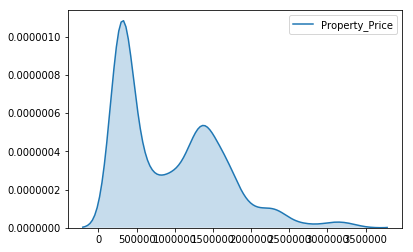

```python
sns.kdeplot(zillow_ts["Property_Price"], shade=True)
```

#### The property values appear reasonably distributed, without any overly extreme values

## 7. Exploratory Data Analysis (EDA)

### (7.1) Objective

> To attain a directional understanding of the current state of the Airbnb rental business and property prices in NYC

### (7.2) Airbnb Data

### (7.2.1) Borough Level

#### The necessary dataset and function is first created to visualize the data

```python
airbnb_borough = airbnb_zip.groupby('Borough',as_index=False).agg({'airbnb_price':'mean', 'num_listings':'sum','occupancy_rate':'mean'})

# function to plot a bar and line chart
def bar_line(x1,x_label, y1,y1_label, y1_label_format, y2,y2_label,y2_label_format, titl, colr):
    y1_max = (y1.max()*1.2)
    p = figure(title=titl, x_range=x1.unique(), y_range= (0,y1_max), plot_height=400, x_axis_label=x_label, y_axis_label=y1_label)

    p.yaxis[0].formatter = NumeralTickFormatter(format=y1_label_format)
    p.vbar(x=x1.unique(), top=y1.unique(), width=0.9, alpha=0.5, legend=y1_label, color=colr)
    y2_max = (y2.max()+500)
    p.extra_y_ranges = {"foo": Range1d(start=0, end=y2_max)}
    p.line(x=x1.unique(), y=y2.unique(), color="red", line_width=3,
       legend=y2_label, y_range_name="foo")
    p.circle(x=x1.unique(), y=y2.unique(), line_color="red", fill_color="white",
         size=10, y_range_name="foo")
    p.add_layout(LinearAxis(y_range_name="foo", axis_label=y2_label),'right')
    p.yaxis[1].formatter = NumeralTickFormatter(format=y2_label_format)
    show(p)
```

```python
# plot airbnb price vs listings
bar_line(airbnb_borough['Borough'],'Boroughs', airbnb_borough['airbnb_price'],"Airbnb Rent", "$0", airbnb_borough['num_listings'],'Number of Listings',"0,0", "Average AirBnb Rent Vs. Available Listings - Mar 2017",'navy')
```

[interactive chart not shown]

#### From the above chart, it is observed that most Airbnb listings are located in Brooklyn and Manhattan.

#### It is also noted that listings in Manhattan have a higher Airbnb rent on average, than that of the other boroughs i.e. listings in Manhattan have a higher earning capacity.

#### Rent in the other 3 boroughs are also found to be competitive to that of Brooklyn's, but have fewer number of listings. This may indicate a sign of demand not being met, and may prove to be an opportunity.

```python
# plot occupancy rate vs listings
bar_line(airbnb_borough['Borough'],'Borough', airbnb_borough['occupancy_rate'],'Occupancy Rate', "%0", airbnb_borough['num_listings'],'Number of Listings',"0,0", "Occupancy Rate Vs. Available Listings - Mar 2017", 'green')
```

[interactive chart not shown]

#### Similar to the trend in Airbnb rent, Manhattan, followed by Brooklyn, also appears to have the highest occupancy rate on average. This again supports the theory of high earning capacity for Airbnb listings in Manhattan.

#### The fair occupancy rates of around 60% in the other 3 boroughs, along with a competitve Airbnb rent and low number of listings, again puts forward the theory of an unrealized opportunity.

### (7.2.2) ZIP Code Level

#### The necessary dataset and function is first created to visualize the data

```python
geo_data = GeoDataFrame(airbnb_zip.merge(zip_codes, how='left', left_on='zipcode', right_on='zip_code'))

def geo_plot2(data, num_plots, y1, y1_color, y1_title, y2, y2_color, y2_title):
    fig, ax = plt.subplots(figsize = (25,10), ncols=num_plots)
    data.plot(column=y1, cmap=y1_color, alpha=10, linewidth=.1, ax=ax[0], legend=True, edgecolor='black')
    ax[0].set_title(y1_title, size=20)
    data.plot(column=y2, cmap=y2_color, alpha=10, linewidth=.1, ax=ax[1], legend=True, edgecolor='black')
    ax[1].set_title(y2_title, size=20)
    plt.show()
```

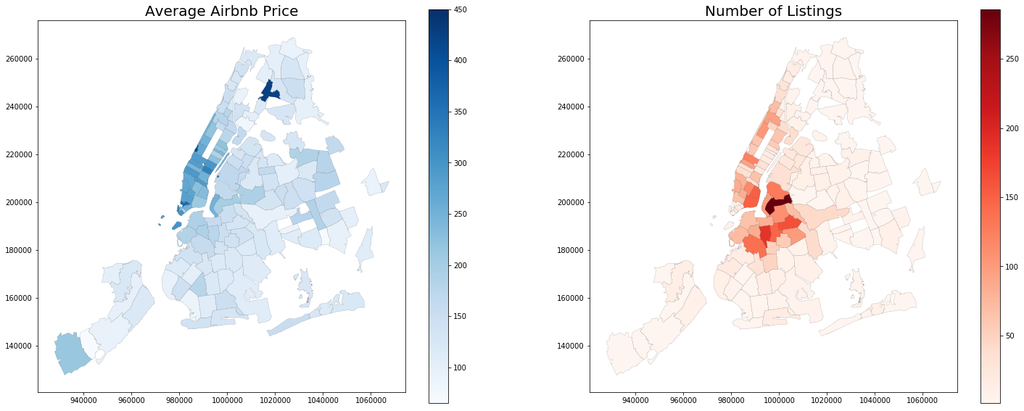

```python
# plot geo mapping for airbnb revenue and number of listings
geo_plot2(geo_data, 2, 'airbnb_price', 'Blues', "Average Airbnb Price", 'num_listings', 'Reds', "Number of Listings")
```

#### A more refined and positional image of the previous findings is now observed when visualized at a ZIP code level i.e. ZIP codes in Manhattan tend to have a higher earning capacity, and that majority of the Airbnb listings are located in Manhattan and Brooklyn.

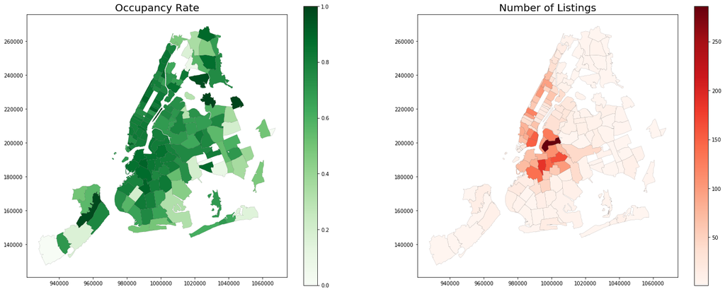

```python
# plot geo mapping for occupancy rate and number of listings
geo_plot2(geo_data, 2, 'occupancy_rate', 'Greens', "Occupancy Rate", 'num_listings', 'Reds', "Number of Listings")
```

#### It is also observed that most listings available throughout New York City have a fair to high occupancy rate

```python
# create scatter plots for combinations airbnb revenue, number of listings and occupancy rate
p1 = figure(plot_width=300, plot_height=300, title="AirBnb Rent Vs. Available Listings", x_axis_label='Average Airbnb Rent', y_axis_label = 'Number of Listings')
p1.circle(airbnb_zip['airbnb_price'],airbnb_zip['num_listings'] , size=5)
p1.xaxis[0].formatter = NumeralTickFormatter(format="$0")
p2 = figure(plot_width=300, plot_height=300, title="Occupancy Rate Vs. Available Listings", x_axis_label='Occupancy Rate', y_axis_label = 'Number of Listings')
p2.circle(airbnb_zip['occupancy_rate'],airbnb_zip['num_listings'] , size=5, color="firebrick")
p2.xaxis[0].formatter = NumeralTickFormatter(format="%0")
p3 = figure(plot_width=300, plot_height=300, title="Occupancy Rate Vs. AirBnb Rent", x_axis_label='Occupancy Rate', y_axis_label = 'Average Airbnb Rent')
p3.circle(airbnb_zip['occupancy_rate'],airbnb_zip['airbnb_price'] , size=5, color="red")
p3.xaxis[0].formatter = NumeralTickFormatter(format="%0")
p3.yaxis[0].formatter = NumeralTickFormatter(format="$0")
show(row(p1,p2,p3))
```

[interactive chart not shown]

#### The scatter plots above also indicate that, most Airbnb listings strive for competitive pricing with high occupancy rates. This suggests that the Airbnb listing business is reasonably competitive.

### (7.3) Zillow Data

#### The necessary dataset and function is first created to visualize the data

```python
zip_cost = pd.merge(airbnb_zip, zillow_zip, how='inner', left_on='zipcode', right_on='zipcode')
borough_value = zip_cost.groupby('Borough',as_index=False).agg({'airbnb_price':'mean', 'num_listings':'sum', 'occupancy_rate':'mean','Current_price':'mean'})

def bar_c(titl, x1, x1_label, y1, y1_label, y1_format, color):
    p = figure(title=titl, x_range=x1, plot_height=400, x_axis_label=x1_label, y_axis_label = y1_label)
    p.yaxis[0].formatter = NumeralTickFormatter(format=y1_format)
    p.vbar(x=x1, top=y1, width=0.9, alpha=0.5, legend=y1_label, color=color)
    show(p)
```

```python
bar_c("Current Property Value at Borough Level", borough_value['Borough'].unique(), 'Boroughs', borough_value['Current_price'].unique(), 'Property Value', "$0,0", "green")
```

[interactive chart not shown]

#### The above chart indicates that property values in Manhattan are 2 times or more, than that of the properties in other boroughs on an average.

#### This calls into question the profitability of investing in Manhattan, given its benifits with respect to Airbnb listings and the high prices of real estate.

## 8. Profitability Analysis: Absolute Influence of the Airbnb Listing Business

### (8.1) Assumptions

> - Prices of real estate remain relatively constant over time

### (8.2) Borough Level

#### A chart is plotted to visualize the time taken to break-even with the initial investment, considering the revenue from Airbnb listings alone

```python
pd.set_option('display.max_rows', 4)
borough_value['annual_revenue'] = borough_value['airbnb_price']*borough_value['occupancy_rate']*365
borough_value['break_even_years'] = borough_value['Current_price']/borough_value['annual_revenue']
bar_c("Borough Level Years to Break-Even", borough_value['Borough'].unique(), 'Boroughs', borough_value['break_even_years'].unique(), 'Avg. Years to Break-Even',  "0,0", "red")
```

[interactive chart not shown]

#### The above chart suggests that property in Staten Island take the least amount of time to break-even with the initial investment as compared to all other boroughs on an average

### (8.3) ZIP Code Level

#### The ZIP codes are mapped to better visualize the time taken to break-even, considering the revenue from Airbnb listings alone

```python
zip_cost['annual_revenue'] = zip_cost['airbnb_price']*zip_cost['occupancy_rate']*365
zip_cost['break_even_years'] = zip_cost['Current_price']/zip_cost['annual_revenue']
# removing records with 0% accupancy
zip_cost = zip_cost[zip_cost['occupancy_rate'] > 0]
geo_1 = GeoDataFrame(zip_cost.merge(zip_codes, how='left', left_on='zipcode', right_on='zip_code'))

# function to plot single geo data
def geo_plot1(data, y1, color, titl):
    fig, ax = plt.subplots(figsize = (15,8))
    data.plot(column=y1, cmap=color, alpha=10000, ax=ax, linewidth=1, legend=True, edgecolor='black')
    ax.set_title(titl, size=15)
    plt.show()
```

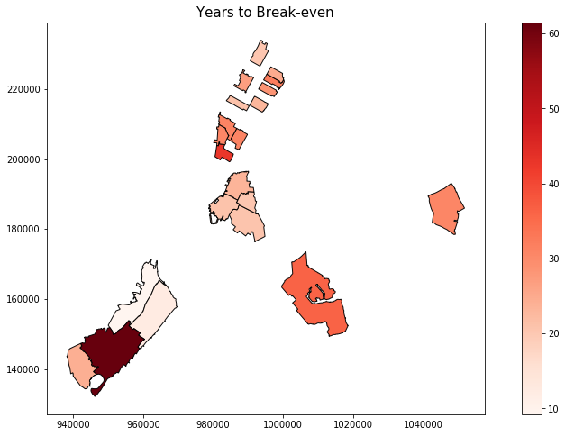

```python
# map years to break-even
geo_plot1(geo_1, 'break_even_years', 'Reds', "Years to Break-even")
```

#### The above chart indicates that ZIP codes in Staten Island have properties that show the highest and least time to break-even. To understand this better, we deep dive into the data.

#### Below is a table with the right most column representing the number of years to break-even (in ascending order)

```python
zip_cost.sort_values(by='break_even_years', inplace=True)
pd.set_option('display.max_rows', 21)
zip_cost
```

|  | zipcode | Borough | airbnb_price | num_listings | occupancy_rate | Current_price | annual_revenue | break_even_years |
| --- | --- | --- | --- | --- | --- | --- | --- | --- |
| 11 | 10304 | Staten Island | 97.0 | 2 | 0.983333 | 321300 | 34814.916667 | 9.228803 |
| 12 | 10305 | Staten Island | 120.0 | 9 | 0.770370 | 418900 | 33742.222222 | 12.414713 |
| 18 | 11217 | Brooklyn | 190.0 | 85 | 0.905882 | 1276400 | 62822.941176 | 20.317419 |
| 7 | 10025 | Manhattan | 220.0 | 103 | 0.848220 | 1390000 | 68112.071197 | 20.407543 |
| 17 | 11215 | Brooklyn | 160.0 | 139 | 0.876499 | 1066200 | 51187.529976 | 20.829292 |
| 19 | 11231 | Brooklyn | 185.0 | 72 | 0.855556 | 1211700 | 57771.388889 | 20.974050 |
| 9 | 10036 | Manhattan | 287.0 | 94 | 0.770922 | 1717100 | 80757.932624 | 21.262308 |
| 5 | 10022 | Manhattan | 298.0 | 34 | 0.798039 | 1997800 | 86802.725490 | 23.015406 |
| 16 | 11201 | Brooklyn | 189.0 | 66 | 0.869697 | 1407300 | 59996.045455 | 23.456546 |
| 14 | 10308 | Staten Island | 65.0 | 1 | 0.700000 | 402900 | 16607.500000 | 24.260123 |
| 10 | 10128 | Manhattan | 220.0 | 56 | 0.861905 | 1720500 | 69210.952381 | 24.858782 |
| 6 | 10023 | Manhattan | 265.0 | 59 | 0.806780 | 2095000 | 78035.762712 | 26.846665 |
| 4 | 10021 | Manhattan | 187.5 | 18 | 0.909259 | 1774100 | 62227.430556 | 28.509935 |
| 21 | 11434 | Queens | 95.0 | 9 | 0.355556 | 380200 | 12328.888889 | 30.838140 |
| 3 | 10014 | Manhattan | 271.0 | 85 | 0.818824 | 2498400 | 80993.929412 | 30.846756 |
| 1 | 10011 | Manhattan | 265.0 | 80 | 0.802917 | 2419700 | 77662.114583 | 31.156762 |
| 0 | 10003 | Manhattan | 226.5 | 116 | 0.816379 | 2109100 | 67492.118534 | 31.249575 |
| 8 | 10028 | Manhattan | 210.0 | 28 | 0.814286 | 2015700 | 62415.000000 | 32.295121 |
| 20 | 11234 | Brooklyn | 110.0 | 6 | 0.327778 | 477100 | 13160.277778 | 36.253034 |
| 2 | 10013 | Manhattan | 279.5 | 66 | 0.745455 | 3262200 | 76049.409091 | 42.895797 |
| 13 | 10306 | Staten Island | 93.0 | 2 | 0.166667 | 347800 | 5657.500000 | 61.475917 |

#### It is found that the extreme variations from ZIP codes in Staten Island are caused by very few data points (num_listings) supporting them. Hence, ZIP codes with less than 10 listings are filtered out. A profitability index is then created to better visualize the profitability.

```python
# creating profitability index though inverse min max scaling of risk
zip_prof_index = pd.DataFrame(zip_cost[['zipcode','break_even_years','num_listings']])
# considering only zip codes with more than 10 listings
zip_prof_index = zip_prof_index[zip_prof_index['num_listings'] > 10]
mx = zip_prof_index.break_even_years.max()
mn = zip_prof_index.break_even_years.min()
zip_prof_index['scaled_risk'] = (zip_prof_index['break_even_years']-mn)/(mx-mn)
zip_prof_index['profit_index'] = 1-zip_prof_index['scaled_risk']
zip_prof_zip = pd.merge(pd.DataFrame(airbnb_zip['zipcode']), zip_prof_index, how='left', left_on='zipcode', right_on='zipcode')
zip_prof_zip = zip_prof_zip.fillna(0)
```

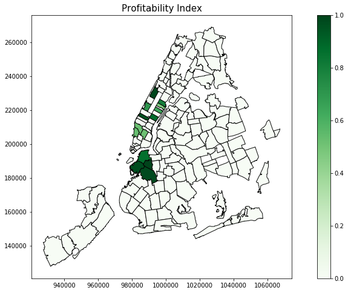

```python
# map profitability index
geo_1 = GeoDataFrame(zip_prof_zip.merge(zip_codes, how='left', left_on='zipcode', right_on='zip_code'))
geo_plot1(geo_1, 'profit_index', 'Greens', "Profitability Index")
```

#### We observe that properties located around Manhattan and Brooklyn take the least amount of time to break-even, as compared to other areas in New York City.

#### It is also noted that relying solely on the revenue from Airbnb rentals require 20+ years to break-even with the initial investment. Hence, we forgo analyzing the profitability in the long run, and proceed to analyze the influence of real estate value over time, on profitability.

## 9. Profitability Analysis: Multi-factor Assessment of Profitability

### (9.1) Borough Level Effect of Time

#### The necessary dataset and visualization is created to understand the borough level effect of property price over time

```python
# filtering for only the zip codes with >10 listings
zillow_ts_fil = zillow_ts[zillow_ts['zipcode'].isin(zip_prof_index['zipcode'])]
# getting borough of each zipcode
zillow_ts_zip = pd.merge(zillow_ts_fil, zip_cost[['zipcode','Borough']], how='left', left_on='zipcode', right_on='zipcode')
zillow_ts_bor = zillow_ts_zip.groupby(['Borough','Date'],as_index=False).agg({'Property_Price':np.mean})
# pivoting the table
zillow_ts_bor_line = pivot_table(zillow_ts_bor, values='Property_Price', index='Date', columns='Borough')
zillow_ts_bor_line = zillow_ts_bor_line.reset_index()

# create a new plot with a datetime axis type
p = figure(plot_width=800, plot_height=500, x_axis_type="datetime", title="Property Price Over Time", x_axis_label='Time', y_axis_label = 'Property Price')
p.line(zillow_ts_bor_line['Date'], zillow_ts_bor_line['Brooklyn'], color='navy', alpha=0.5, line_width=3, legend='Brooklyn')
p.line(zillow_ts_bor_line['Date'], zillow_ts_bor_line['Manhattan'], color='red', alpha=0.5, line_width=3, legend='Manhattan')
p.yaxis[0].formatter = NumeralTickFormatter(format="$0,0")
p.legend.location = "top_left"
show(p)
```

[interactive chart not shown]

#### From the above chart, it is observed that property values have historically had an upward trend over time. This increase in property value may help in breaking even, even quicker, in addition to the revenue from Airbnb rentals.

### (9.2) ZIP Code Level Effect of Time

#### The necessary dataset and visualization is created to understand the ZIP code level effect of property price over time

```python
zillow_ts_zip_line = pivot_table(zillow_ts_fil, values='Property_Price', index='Date', columns='zipcode')
zillow_ts_zips = zillow_ts_zip_line.columns

# plotting for all zip codes
p = figure(plot_width=800, plot_height=500, x_axis_type="datetime", toolbar_location='above', x_axis_label='Time', y_axis_label = 'Property Price')
p.title.text = 'Click on legend entries to mute the corresponding lines'
legend_it = []
colors = itertools.cycle(palette)
for i, color in zip(zillow_ts_zip_line.columns, colors):
    c = p.line(zillow_ts_zip_line.index, zillow_ts_zip_line[i], line_width=2, color=color, alpha=0.8, muted_color=color, muted_alpha=0.2)
    legend_it.append((str(i), [c]))
p.yaxis[0].formatter = NumeralTickFormatter(format="$0,0")
legend = Legend(items=legend_it, location=(0, 0))
legend.click_policy="mute"
p.add_layout(legend, 'right')
show(p)
```

[interactive chart not shown]

#### It is observed that all the ZIP codes of interest have historically had an an upward trend in property value over time.

### (9.3) Time Series Forecasting at ZIP Code Level

#### Autoregressive Integrated Moving Average (ARIMA) time series models are created for each individual ZIP code of interest, to forecast the increase in property value over time within them.

#### The property value over time for a single ZIP code is first visualized.

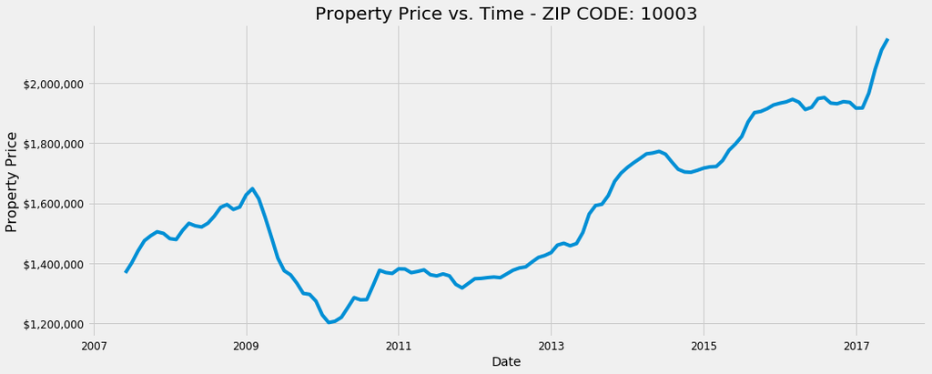

```python
y = zillow_ts_zip_line.iloc[:,0]
y_col_name = zillow_ts_zip_line.columns[0]

plt.style.use('fivethirtyeight')
matplotlib.rcParams['axes.labelsize'] = 14
matplotlib.rcParams['xtick.labelsize'] = 12
matplotlib.rcParams['ytick.labelsize'] = 12
matplotlib.rcParams['text.color'] = 'k'

ax = y.plot(figsize=(15, 6), title=(('Property Price vs. Time - ZIP CODE: ' + str(y_col_name))))
plt.ylabel('Property Price', fontsize=16)
vals = ax.get_yticks()
ax.set_yticklabels(['${:,.0f}'.format(x) for x in vals])
plt.show()
```

#### The time series is then decomposed into it's trend, seasonal and noise components, and then visualized

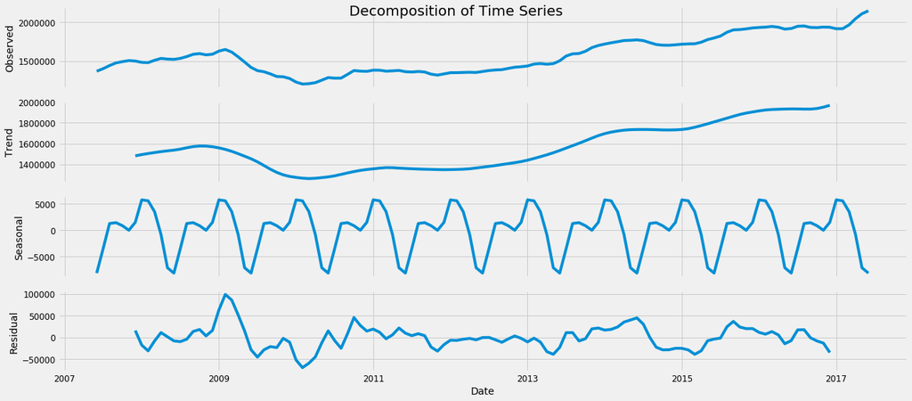

```python
# Decomposing TS to trend seasonality and noise
rcParams['figure.figsize'] = 18, 8
decomposition = sm.tsa.seasonal_decompose(y, model='additive')
fig = decomposition.plot()
fig.suptitle('Decomposition of Time Series', fontsize=20)
plt.show()
```

#### A clear trend and seasonal pattern is observed in the above chart.

#### A parameter grid is then created to run a 'grid search' to find the optimal set of parameters that yeilds the best performance for the model. The parameters are selected based on the model that generates the lowest AIC.

```python
# creating a grid of parameters
warnings.filterwarnings('ignore')
p = d = q = range(0, 2)
pdq = list(itertools.product(p, d, q))
seasonal_pdq = [(x[0], x[1], x[2], 12) for x in list(itertools.product(p, d, q))]
# choosing the best parameters (grid search)
best_aic = 1000000.00
for param in pdq:
    for param_seasonal in seasonal_pdq:
        try:
            mod = sm.tsa.statespace.SARIMAX(y,
                                            order=param,
                                            seasonal_order=param_seasonal,
                                            enforce_stationarity=False,
                                            enforce_invertibility=False)
            results = mod.fit()
            if results.aic < best_aic:
                best_para = param
                best_para_seas = param_seasonal
                best_aic = results.aic
        except:
            continue
```

#### An ARIMA model is then fitted to the time series using the best parameters found

```python
# Fitting ARIMA model with best parameters
mod = sm.tsa.statespace.SARIMAX(y, order=best_para, seasonal_order=best_para_seas, enforce_stationarity=False, enforce_invertibility=False)
results = mod.fit()
print(results.summary().tables[1])
```

```
==============================================================================
                 coef    std err          z      P>|z|      [0.025      0.975]
------------------------------------------------------------------------------
ar.L1          0.4603      0.192      2.396      0.017       0.084       0.837
ma.L1          0.3213      0.109      2.940      0.003       0.107       0.535
ar.S.L12      -0.6259      0.142     -4.398      0.000      -0.905      -0.347
ma.S.L12      -0.0520      0.061     -0.857      0.391      -0.171       0.067
sigma2      6.479e+08   1.62e-11   4.01e+19      0.000    6.48e+08    6.48e+08
==============================================================================
```

#### The model diagnostic is then run to investigate any unusual behavior

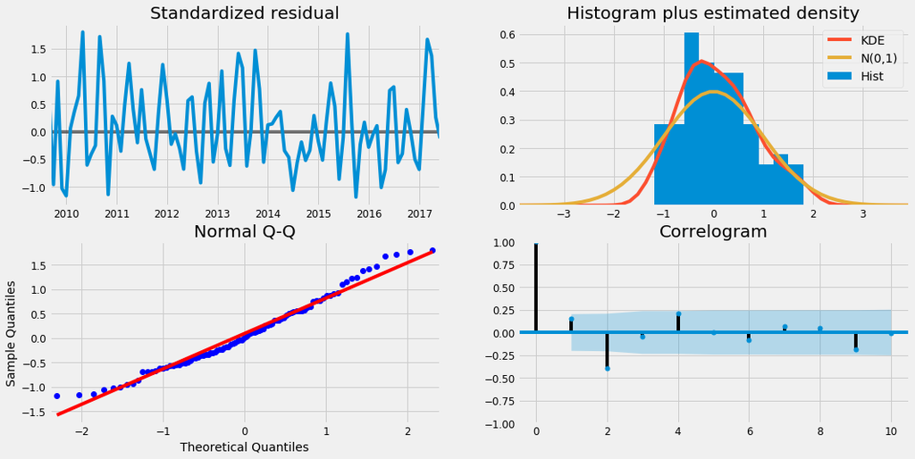

```python
results.plot_diagnostics(figsize=(16, 8))
plt.show()
```

#### The model diagnostics suggests that the model residuals are near normally distributed.

#### The model forecast is then visualized with the true value to help visually validate the forecast.

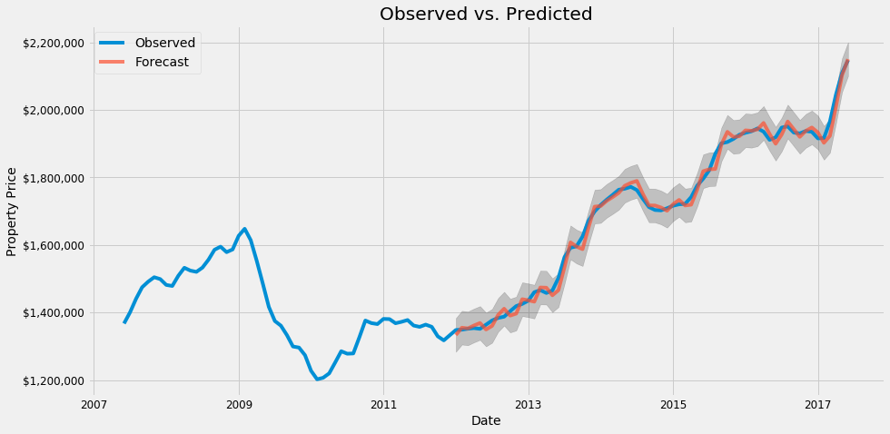

```python
# validating forecast
pred = results.get_prediction(start=pd.to_datetime('2012-01-01'), dynamic=False)
pred_ci = pred.conf_int()
ax = y['2007':].plot(label='Observed')
pred.predicted_mean.plot(ax=ax, label='Forecast', alpha=.7, figsize=(14, 7))
ax.fill_between(pred_ci.index, pred_ci.iloc[:, 0], pred_ci.iloc[:, 1], color='k', alpha=.2)
ax.set_xlabel('Date')
ax.set_ylabel('Property Price')
vals = ax.get_yticks()
ax.set_yticklabels(['${:,.0f}'.format(x) for x in vals])
plt.title('Observed vs. Predicted')
plt.legend()
plt.show()
```

#### The MSE and RMSE are then calculated to assess the error in the forecast

```python
y_forecasted = pred.predicted_mean
y_truth = y['2012-01-01':]
mse = ((y_forecasted - y_truth) ** 2).mean()
print('The Mean Squared Error of our forecasts is {}'.format(round(mse, 2)))
print('The Root Mean Squared Error of our forecasts is {}'.format(round(np.sqrt(mse), 2)))
```

```
The Mean Squared Error of our forecasts is 305668638.29
The Root Mean Squared Error of our forecasts is 17483.38
```

#### Root Mean Square Error (RMSE) tells us that our model was able to forecast the average monthly property value within $17,483 of the true property value. This is fairly good considering the true property value is in the millions.

#### Forecasts are then made into the future and visualized.

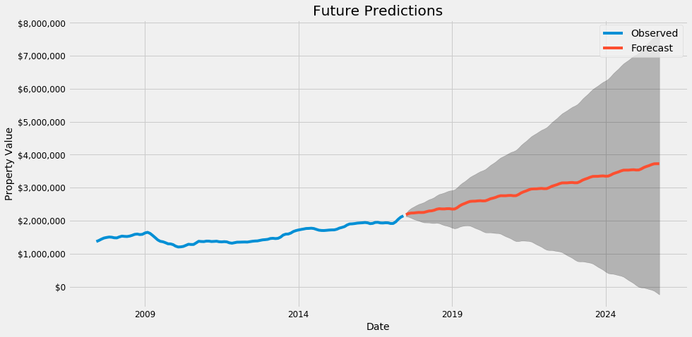

```python
pred_uc = results.get_forecast(steps=100)
pred_ci = pred_uc.conf_int()
ax = y.plot(label='Observed', figsize=(14, 7))
pred_uc.predicted_mean.plot(ax=ax, label='Forecast')
ax.fill_between(pred_ci.index, pred_ci.iloc[:, 0], pred_ci.iloc[:, 1], color='k', alpha=.25)
ax.set_xlabel('Date')
ax.set_ylabel('Property Value')
vals = ax.get_yticks()
ax.set_yticklabels(['${:,.0f}'.format(x) for x in vals])
plt.title('Future Predictions')
plt.legend()
plt.show()
```

#### A main dataset is created to hold the forecasts of the remaining ZIP codes

```python
pred_uc = results.get_forecast(steps=200)
forecast_1 = pd.DataFrame(pred_uc.predicted_mean, columns=[str(y_col_name)])
forecast_1_npv = forecast_1
forecast_1_npv['Current_price'] = float(zip_cost[zip_cost['zipcode']==y_col_name]['Current_price'])
forecast_1_npv['monthly_revenue'] = float((zip_cost[zip_cost['zipcode']==y_col_name]['annual_revenue'])/12)
forecast_1_npv['NPV_pre'] = (-forecast_1_npv['Current_price']) + (forecast_1_npv[str(y_col_name)] - forecast_1_npv['Current_price']) + forecast_1_npv['monthly_revenue']
forecast_1_npv['NPV'] = forecast_1_npv['NPV_pre'].shift(1) + forecast_1_npv['monthly_revenue']
forecast_zip = pd.DataFrame(forecast_1_npv['NPV']).rename(columns={'NPV':y_col_name})
forecast_final = forecast_zip
```

#### An ARIMA time series model is now created for all the remaining zip codes

```python
for i in range(1,15):
    y = zillow_ts_zip_line.iloc[:,i]
    y_col_name = zillow_ts_zip_line.columns[i]
    best_aic = 1000000.00
    for param in pdq:
        for param_seasonal in seasonal_pdq:
            try:
                mod = sm.tsa.statespace.SARIMAX(y, order=param, seasonal_order=param_seasonal, enforce_stationarity=False, enforce_invertibility=False)
                results = mod.fit()
                if results.aic < best_aic:
                    best_para = param
                    best_para_seas = param_seasonal
                    best_aic = results.aic
            except:
                continue
    mod = sm.tsa.statespace.SARIMAX(y, order=best_para, seasonal_order=best_para_seas, enforce_stationarity=False, enforce_invertibility=False)
    results = mod.fit()
    # checking rmse
    pred = results.get_prediction(start=pd.to_datetime('2012-01-01'), dynamic=False)
    y_forecasted = pred.predicted_mean
    y_truth = y['2012-01-01':]
    mse = ((y_forecasted - y_truth) ** 2).mean()
    print('The Root Mean Squared Error of the forecast of zip code {} is {}'.format(y_col_name,'${:,.2f}'.format(round(np.sqrt(mse), 2))))
    #make predictions
    pred_uc = results.get_forecast(steps=200)
    #find NPV over time
    forecast_1 = pd.DataFrame(pred_uc.predicted_mean, columns=[str(y_col_name)])
    forecast_1_npv = forecast_1
    forecast_1_npv['Current_price'] = float(zip_cost[zip_cost['zipcode']==y_col_name]['Current_price'])
    forecast_1_npv['monthly_revenue'] = float((zip_cost[zip_cost['zipcode']==y_col_name]['annual_revenue'])/12)
    forecast_1_npv['NPV_pre'] = (-forecast_1_npv['Current_price']) + (forecast_1_npv[str(y_col_name)] - forecast_1_npv['Current_price']) + forecast_1_npv['monthly_revenue']
    forecast_1_npv['NPV'] = forecast_1_npv['NPV_pre'].shift(1) + forecast_1_npv['monthly_revenue']
    forecast_zip = pd.DataFrame(forecast_1_npv['NPV']).rename(columns={'NPV':y_col_name})
    # merge to master predicted dataframe
    forecast_final = pd.merge(forecast_final, forecast_zip, how='inner', left_index=True, right_index=True)
```

```
The Root Mean Squared Error of the forecast of zip code 10011 is $14,988.17
The Root Mean Squared Error of the forecast of zip code 10013 is $25,562.74
The Root Mean Squared Error of the forecast of zip code 10014 is $24,680.52
The Root Mean Squared Error of the forecast of zip code 10021 is $11,536.48
The Root Mean Squared Error of the forecast of zip code 10022 is $18,893.99
The Root Mean Squared Error of the forecast of zip code 10023 is $14,059.65
The Root Mean Squared Error of the forecast of zip code 10025 is $10,341.64
The Root Mean Squared Error of the forecast of zip code 10028 is $16,507.07
The Root Mean Squared Error of the forecast of zip code 10036 is $11,740.35
The Root Mean Squared Error of the forecast of zip code 10128 is $12,426.73
The Root Mean Squared Error of the forecast of zip code 11201 is $6,716.81
The Root Mean Squared Error of the forecast of zip code 11215 is $5,701.26
The Root Mean Squared Error of the forecast of zip code 11217 is $9,122.46
The Root Mean Squared Error of the forecast of zip code 11231 is $8,604.69
```

### (9.4) Plotting Net Present Value (NPV) over Time

```python
p = figure(plot_width=800, plot_height=500, x_axis_type="datetime", toolbar_location='above', x_axis_label='Time', y_axis_label = 'Net Present Value')
p.title.text = 'Click on legend entries to mute the corresponding lines'
legend_it = []
colors = itertools.cycle(palette)
for i, color in zip(forecast_final.columns, colors):
    c = p.line(forecast_final.index, forecast_final[i], line_width=2, color=color, alpha=0.8, muted_color=color, muted_alpha=0.2)
    legend_it.append((str(i), [c]))
c = p.line(forecast_final.index, 0, line_width=3, color='red', alpha=1)
p.yaxis[0].formatter = NumeralTickFormatter(format="$0,0")
legend = Legend(items=legend_it, location=(0, 0))
legend.click_policy="mute"
p.add_layout(legend, 'right')
show(p)
```

[interactive chart not shown]

#### The above chart indicates that investment in a property at ZIP codes 10028 and 10128, is estimated to to break-even the earliest, i.e. in around 6 years (around Jun, 2023).

#### Investment in a property at these ZIP codes is also estimated to generate the most incremental profit in the long run, e.g. it would be valued at ~$2M in profits (inclusive of revenue from Airbnb) over the next 12 years (Jan, 2030)

#### Investment in a property at the second tier of best ZIP codes, 10022 and 10023, is also estimated to generate similar results. Investment in a property here is estimated to break-even in around 8 years (around May, 2025). It would also be estimated to be valued at ~$1.3M in profits (inclusive of revenue from Airbnb) over the next 12 years (Jan, 2030)

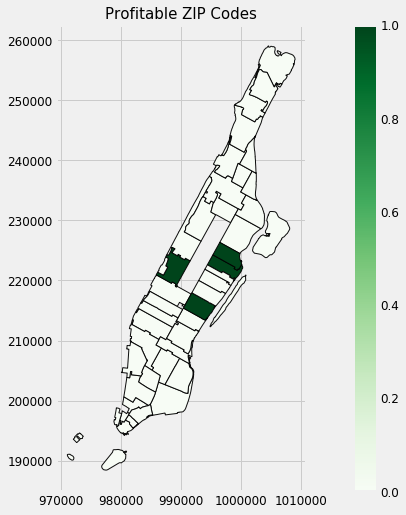

```python
final = pd.DataFrame({'zipcode':[10028, 10128, 10022, 10023], 'profit':[1,1,1,1]})
manhattan = airbnb_zip[airbnb_zip['Borough']=='Manhattan']
fin = pd.merge(pd.DataFrame(manhattan['zipcode']), final, how='left', left_on='zipcode', right_on='zipcode')
fin = fin.fillna(0)
geo_1 = GeoDataFrame(fin.merge(zip_codes, how='left', left_on='zipcode', right_on='zip_code'))
geo_plot1(geo_1, 'profit', 'Greens', 'Profitable ZIP Codes')
```

## 10. Recommendations

> - Investments in property should primarily be made around the Upper East Side of Manhattan (ZIP codes: 10028, 10128).
> - Investments in property, subject to additional availability of capital, should also be made around the southern area of the Upper East Side of Manhattan (ZIP code: 10022) and around the Upper West Side of Manhattan (ZIP code: 10023).
> - Diversification of investment among these ZIP codes is highly recommended to minimize risk.

## 11. Next Steps

> - Collect more data from the Airbnb and Zillow websites to attain more data points to better validate our current findings.
> - Post puschase of profitable property, analysis can be performed on the myraid of text data available in the Airbnb dataset to optimize revenue generated.
>   - Analysis on this data may provide valuable insight on how to list and operate the property on Airbnb to optimize occupancy rate and rent. Techniques such as NLP, sentiment analysis & topic modelling could be implemented here.
> - Airbnb data as a time series can be leveraged to account for the seasonal fluctuations in occupancy.
> - Discount rate and mortgages can be accounted for. to derive a more realistic valuation of the property.

## 12. References

> - Visualizations:
>   - https://bokeh.pydata.org/en/latest/
>   - https://stackoverflow.com/questions/46730609/position-the-legend-outside-the-plot-area-with-bokeh
> - AirBnB Dataset:
>   - http://insideairbnb.com/get-the-data.html
> - Zillow Dataset:
>   - https://www.zillow.com/research/data/
> - NYC ZIP Code Boundaries and Information:
>   - https://data.cityofnewyork.us/Business/Zip-Code-Boundaries/i8iw-xf4u/data
> - Geo Map Plotting:
>   - http://geopandas.org/
>   - https://data.cityofnewyork.us/Business/Zip-Code-Boundaries/i8iw-xf4u/data
>   - https://docs.enigma.com/public/public_v20_user_data_tutorial.html
> - Time Series:
>   - https://towardsdatascience.com/an-end-to-end-project-on-time-series-analysis-and-forecasting-with-python-4835e6bf050b